# Math 421 - Midterm

## Instruction

The midterm has two components: the Rmarkdown notebook (html) and the presentation. We will do the presentation in class. Post both the notebook and the presentation on your Github page.

**The notebook:** The notebook should be created using `rmarkdown` (like other assignments). The notebook should have a title. It should have a table of content (TOC form) or in a tab form. The Rmd files of Tab and Toc form are available on the class webpage.

**The Presentation:** Present your results in 5-10 minutes. To make the presentation using Rmarkdown, do the follows:

```
- In Rstudio -> File -> New File -> R markdown

- In the left panel, click to Presentation -> Click OK

- Now you have an Rmarkdown that can be knitted to be a html presentation
```

- You can also use Rmd samples of the class slides that are available on the class webpage.
- You do not need to rerun all the codes for the presentation. For example, to show the model comparison, you just need to show the image of the model comparison instead of running all the models again.
- To inset an image in a slide, use `![](image.png)`
- To scale images, you can follow these below instructions.
  - https://bookdown.org/yihui/rmarkdown-cookbook/figure-size.html
  - http://zevross.com/blog/2017/06/19/tips-and-tricks-for-working-with-images-and-figures-in-r-markdown-documents/
- To turn off message and warning of a code cell, use: `{r, message=FALSE, warning=FALSE}` for the cell.

**What to present**:

- Present Part 2 - Visualization
- Present Question Question 4, 5 and 6 in Part 3.
- Present any errors/challenges you run into and how you fix/overcome them.

**Data:**

The data for the mid-term project is the Rhode Island Department of Health Hospital Discharge Data. Each row of the data presents a patient.

Link: https://drive.google.com/open?id=15QNBf6YYKocK2nNIfpKDer58kQnCPNZJ

## I. Data Wranggling

1. Download the data file `hdd0318cy.sas7bdat`.
2. Use `read_sas` in library `haven` to read the data.

```r
library(haven)
df <- read_sas('hdd0318cy.sas7bdat')
```

3. Filter the data to have only patients of the year 2018 (`yod=2018`)

```r
library(tidyverse)
library(dplyr)
df <- df %>% filter(yod=='18')
```

4. Select to work with only following variables:

```r
df <- df %>% select("yod", "payfix","pay_ub92","age",
                      "sex","raceethn","provider","moa",
                      "yoa","mod","admtype", "asource" ,
                      "preopday" ,"los", "service" , "icu","ccu",
                      "dispub92", "payer"  ,"drg","trandb",
                      "randbg","randbs","orr", "anes","seq",
                      "lab","dtest", "ther","blood","phar",
                      "other","patcon","bwght","total","tot" ,
                      "ecodub92","b_wt","pt_state","diag_adm","ancilar" ,
                      "campus","er_fee","er_chrg","er_mode","obs_chrg",
                      "obs_hour","psycchrg","nicu_day")
```

*Notice*: You may want to save the current data to your computer for easy access later. To save the data file use `write_csv(df, 'midterm.csv')`, for example.

```r
write_csv(df, 'midterm.csv')
```

5. What are variables that have missing values?

```r
colSums(is.na(df))
```

[output not shown]

In this dataframe, ‘nicu_day’, ‘obs_hour’, ‘preopday’, and ‘pay_fix’ are the four variables that have missing data.

6. Remove all variables with missing values.

```r
df %>% select(-payfix, -preopday, -obs_hour, -nicu_day)
```

[output not shown]

7. Refer to the data description in the file `HDD2015-18cy6-20-19.docx`, which variable recording the month of admission?, which variable recording the month of discharge?

The Variable ‘MOA’ is recording month of admission and the variable ‘MOD’ is recording month of discharge.

8. Which month admitted the most number of patients? Which month admitted the most number of male patients?

```r
table(df$moa)
```

```
##
##     1     2     3     4     5     6     7     8     9    10    11    12
## 11309 10259 11073 11174 11404 10690 10962 11199 10666 11408 10636 10698
```

Month 10 (October) was the month to record the most patients with a number of 11,408.

```r
df2 <- df %>% filter(sex=='1')
table(df2$moa)
```

```
##
##    1    2    3    4    5    6    7    8    9   10   11   12
## 4970 4546 4978 4989 5066 4810 4910 5028 4683 5164 4800 4855
```

October also ended up being the month with the most male patients admitted, with a number of 5,164 male patients.

9. Which month has the most number of teenage female patients?

```r
df3 <- df %>% filter(sex=='2', age>='13', age <='19')
table(df3$moa)
```

```
##
##   1   2   3   4   5   6   7   8   9  10  11  12
## 207 172 226 187 220 169 171 172 196 212 177 208
```

Month 3 (March) ended up being the month who admitted the most teen female patients with a number of 226.

10. Which provider has the most number of female patients in October?

```r
df %>% filter(sex=='2', moa=='10') %>% count(provider) %>% arrange(-n)
```

```
## # A tibble: 12 × 2
##    provider     n
##    <chr>    <int>
##  1 7205      1517
##  2 7214      1224
##  3 7204       872
##  4 7210       699
##  5 7209       351
##  6 7206       333
##  7 7213       317
##  8 7201       294
##  9 7216       256
## 10 7202       212
## 11 7211       122
## 12 7215        46
```

Provider ‘7205’ had the highest female patients in October with the number 1,517.

11. Are female patients older than male patients, on average?

```r
df %>% group_by(sex) %>% summarise(mean(age))
```

```
## # A tibble: 3 × 2
##   sex   `mean(age)`
##   <chr>       <dbl>
## 1 1            51.5
## 2 2            50.9
## 3 9            43
```

Mean age for male patients came out to be 51.49, and mean age for females came out to be 50.86. This means that on average, male patients were older.

12. Calculate the average age of patients by months. Which month has the oldest patients on average age?

```r
df %>% group_by(moa) %>% summarise(mean(age))
```

```
## # A tibble: 12 × 2
##      moa `mean(age)`
##    <dbl>       <dbl>
##  1     1        51.8
##  2     2        51.2
##  3     3        51.1
##  4     4        51.4
##  5     5        50.6
##  6     6        51.5
##  7     7        51.3
##  8     8        50.9
##  9     9        50.6
## 10    10        50.8
## 11    11        51.0
## 12    12        51.5
```

On average, month 1 had the oldest patients with an average age of 51.792.

13. What is the name of the provider that has the highest total charge?

```r
df %>% group_by(provider) %>% summarise(max(total))
```

```
## # A tibble: 12 × 2
##    provider `max(total)`
##    <chr>    <chr>
##  1 7201     0000365044
##  2 7202     0001477944
##  3 7204     0001040507
##  4 7205     0002991708
##  5 7206     0000802758
##  6 7209     0000282223
##  7 7210     0001375171
##  8 7211     0000331604
##  9 7213     0000608086
## 10 7214     0003402056
## 11 7215     0002418518
## 12 7216     0001532326
```

Provider ‘7214’ has the highest total charge with a total of 0003402056.

14. What is the name of the provider that has the least total charge for teenage male on average?

```r
df %>% filter(sex=='1', age>='13', age <='19') %>% group_by(provider) %>% summarise(min(total))
```

```
## # A tibble: 12 × 2
##    provider `min(total)`
##    <chr>    <chr>
##  1 7201     0000003658
##  2 7202     0000007797
##  3 7204     0000009709
##  4 7205     0000003272
##  5 7206     0000002275
##  6 7209     0000008982
##  7 7210     0000003858
##  8 7211     0000006093
##  9 7213     0000005293
## 10 7214     0000028950
## 11 7215     0000005193
## 12 7216     0000000322
```

15. Create a season (Spring, Summer, Fall, Winter) variable. Calculate the length of stays by season. Which season has the longest length of stays on average?

```r
df$season = case_when(df$moa %in% c(11,12,1) ~ 'Winter',df$moa %in% c(2,3,4,5) ~ 'Spring',df$moa %in% c(6,7,8) ~ 'Summer',df$moa %in% c(9,10,11) ~ 'Fall')
```

```r
df %>% group_by(season) %>% summarise(mean(los))
```

```
## # A tibble: 4 × 2
##   season `mean(los)`
##   <chr>        <dbl>
## 1 Fall          4.96
## 2 Spring        4.84
## 3 Summer        4.96
## 4 Winter        4.96
```

16. On average, how much a 20 year-old male get charged for staying 1 day in the Fall season?

```r
df %>%
  mutate(total = as.factor(total))
```

[output not shown]

```r
df %>% filter(sex=='1', age=='20', season=='Fall', los=='1') %>% summarise(mean(total))
```

```
## # A tibble: 1 × 1
##   `mean(total)`
##           <dbl>
## 1            NA
```

17. Write a paragraph to summarize the section and give your comments on the results. You could do some other calculations to support your points.

## II. Data Visualization

Continue with the data from part I.

1. Provides at least 10 meaningful plots. Comments on the plots. All plots should have title, caption, appropriate labels on x and y-axis

```r
library(gapminder)
library(gganimate)
library(ggplot2)
library(tidyverse)
library(lubridate)
library(knitr)
```

Plot 1

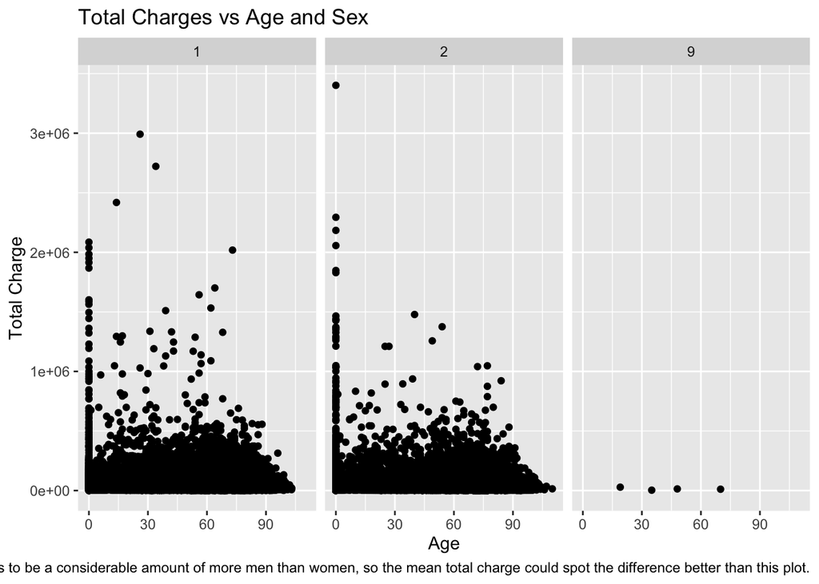

```r
df %>% ggplot()+
  geom_point(mapping=aes(x=age, y=tot))+
  facet_wrap(~sex) + labs(x='Age',
       y = 'Total Charge',
       title = 'Total Charges vs Age and Sex',
       caption = 'There does not seem to be any real difference between male and female total charges, although there seems to be a considerable amount of more men than women, so the mean total charge could spot the difference better than this plot.')
```

Observation: There does not seem to be any real difference between male and female total charges, although there seems to be a considerable amount of more men than women, so the mean total charge could spot the difference better than this plot.

Plot 2

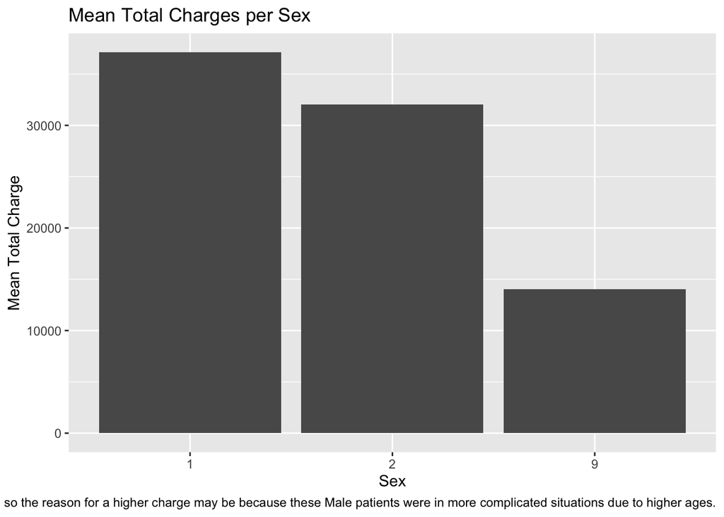

```r
df %>% group_by(sex) %>% summarise(mean_total = mean(tot, na.rm=TRUE)) %>% ggplot()+
  geom_col(mapping=aes(x=sex, y=mean_total))+ labs(x='Sex',
       y = 'Mean Total Charge',
       title = 'Mean Total Charges per Sex',
       caption = 'By computing the mean total charges we can in fact see that on average, men had slightly higher total charges than women. Referencing to one of the calculations made in step 1, men did have a slightly higher average age than women, so the reason for a higher charge may be because these Male patients were in more complicated situations due to higher ages.')
```

Observation: By computing the mean total charges we can in fact see that on average, men had slightly higher total charges than women. Referencing to one of the calculations made in step 1, men did have a slightly higher average age than women, so the reason for a higher charge may be because these Male patients were in more complicated situations due to higher ages.

Plot 3

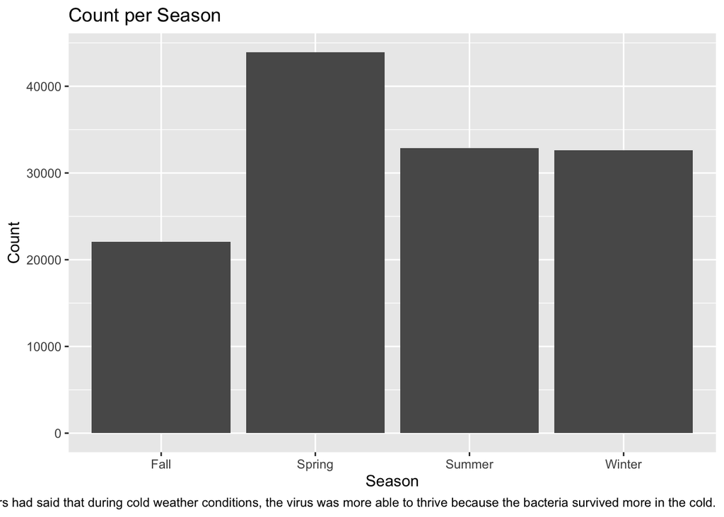

```r
df %>% ggplot()+
  geom_bar(mapping=aes(x=season))+ labs(x='Season',
       y = 'Count',
       title = 'Count per Season',
       caption = 'Spring seems to be the season in which most patients were affected which is a surprising find as I thought it would have been Winter. Doctors had said that during cold weather conditions, the virus was more able to thrive because the bacteria survived more in the cold.')
```

Observation: Spring seems to be the season in which most patients were affected which is a surprising find as I thought it would have been Winter. Doctors had said that during cold weather conditions, the virus was more able to thrive because the bacteria survived more in the cold.

Plot 4

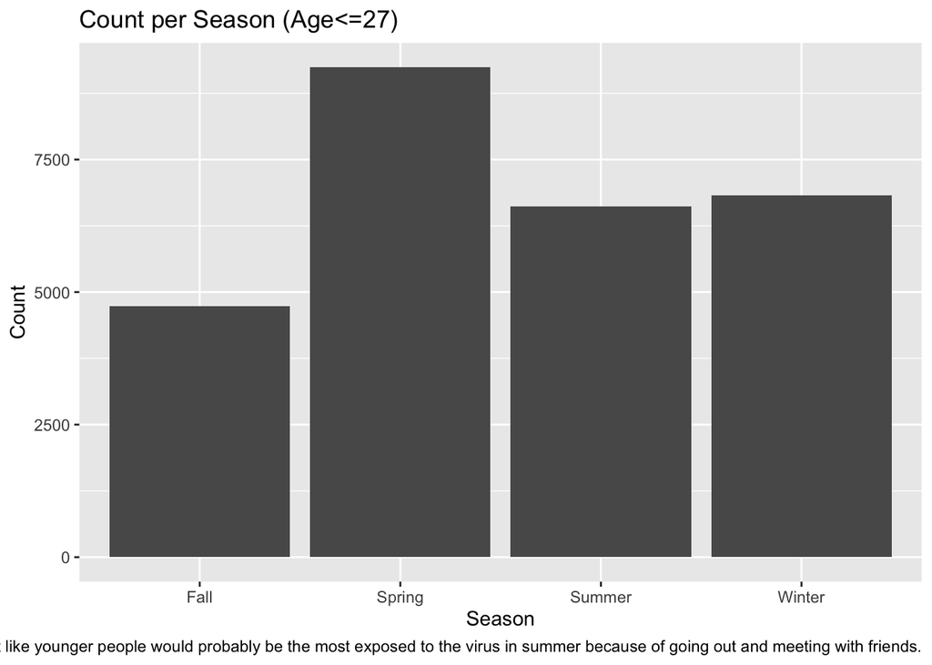

```r
df %>% filter(age<=27) %>% ggplot()+
  geom_bar(mapping=aes(x=season))+ labs(x='Season',
       y = 'Count',
       title = 'Count per Season (Age<=27)',
       caption = 'I decided to take the previous plot and try to spot some changed in behaviour and see how it affected the count per season. Spring seems to be the season where most young people were affected, and it is a surprising find for me because I thought it would have been Summer. I felt like younger people would probably be the most exposed to the virus in summer because of going out and meeting with friends.')
```

Small Observation: I decided to take the previous plot and try to spot some changed in behaviour and see how it affected the count per season. Spring seems to be the season where most young people were affected, and it is a surprising find for me because I thought it would have been Summer. I felt like younger people would probably be the most exposed to the virus in summer because of going out and meeting with friends.

Plot 5

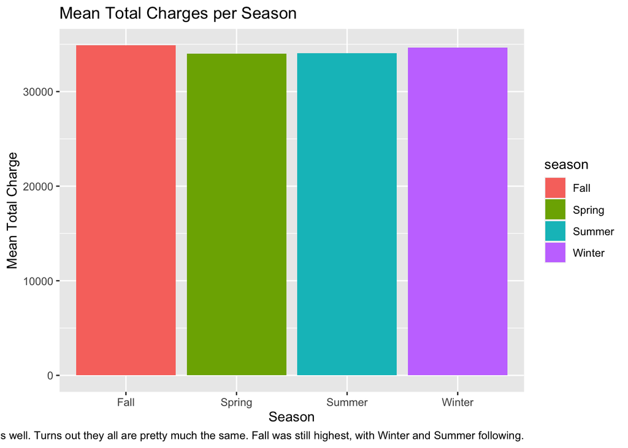

```r
df %>% group_by(season) %>% summarise(mean_total = mean(tot, na.rm=TRUE)) %>% ggplot()+
  geom_col(mapping=aes(x=season, y=mean_total, fill = season))+ labs(x='Season',
       y = 'Mean Total Charge',
       title = 'Mean Total Charges per Season',
       caption = 'I wanted to see if total charges for patients varied throughout the seasons, as rent and electricity charges may vary during holiday periods and extreme weather periods, therefore total charges as well. Turns out they all are pretty much the same. Fall was still highest, with Winter and Summer following.')
```

Observation: I wanted to see if total charges for patients varied throughout the seasons, as rent and electricity charges may vary during holiday periods and extreme weather periods, therefore total charges as well. Turns out they all are pretty much the same.

Plot 6

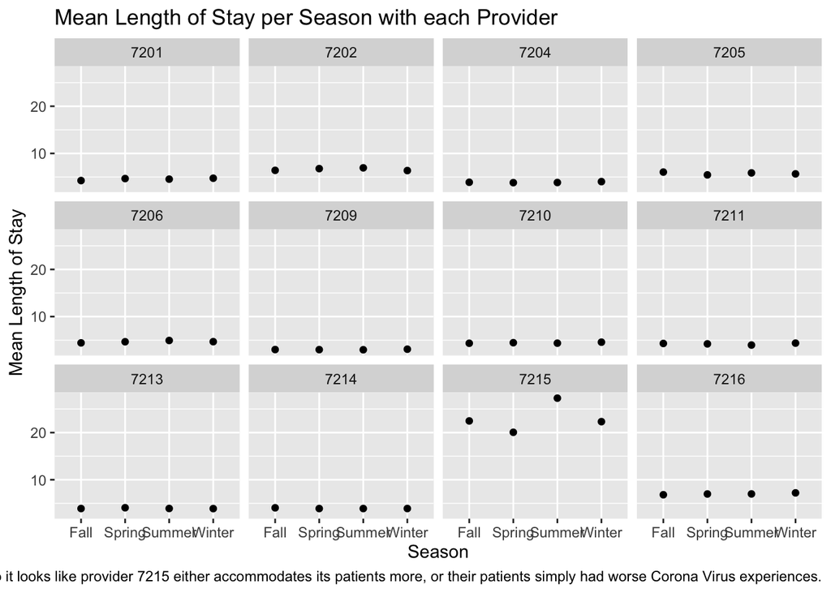

```r
df %>% group_by(season, provider) %>% summarise(mean_los = mean(los)) %>% ggplot()+
  geom_point(mapping=aes(x=season, y=mean_los))+facet_wrap(~provider)+ labs(x='Season',
       y = 'Mean Length of Stay',
       title = 'Mean Length of Stay per Season with each Provider',
       caption = 'From this plot, we can clearly see that provider 7215 has the highest average length of stays in general. When breaking it down to each season, they also have the highest averages per season, so it looks like provider 7215 either accommodates its patients more, or their patients simply had worse Corona Virus experiences.')
```

Observation: From this plot, we can clearly see that provider ‘7215’ has the highest average length of stays in general. When breaking it down to each season, they also have the highest averages per season, so it looks like provider 7215 either accommodates its patients more, or their patients simply had worse Corona Virus experiences.